# Season report: 4545 Season 16

[figure not shown]

### Overview

- The [season](https://www.lichess4545.com/team4545/season/16/summary/) was played from 18 February 2019 to 15 April 2019.
- 279 players took part, playing 808 games in total. The season’s forfeit rate was 9.8 per cent.[^1]
- White won 356 games (44.1%), 136 games (16.8%) were drawn, and Black won 289 games (35.8%).[^2]
- 514 games ended with a resignation, 143 games by checkmate, 12 games by time running out, and 4 games by stalemate.

[figure not shown]

1st place

[Lichess Lovers](https://www.lichess4545.com/team4545/season/16/team/23/)

2nd place

3rd place

| Gold | Silver | Bronze |
| --- | --- | --- |
| Calcium237 (8) | darubaru (8) | Assassin_in_White (8) |
| jessehf (8) | pepepibote (8) | poopheaderic (7) |
| leo2dipikke (8) | CamelClutcher (7) | oddsox (6) |
| paolone (8) | david-innes (7) | Showboater (6) |
| Toffeeman (8) | ma1ah (7) | Tinkerphyte (6) |
| LucaGaglia73 (7) | mattcrossette (7) | yvettenicole (6) |
| Pedropablo72 (7) | Tranzoo (7) | ahmt92 (5) |
| rampichino (7) | gokuba (6) | dkillian (5) |
|  | Dazzles (1) | AleksisKaarlo (2) |
|  |  | AUroach (1) |

[output cut: 4 more lines]

#### Story of the season

[figure not shown]

#### Top of the boards

The top player performances by board (minimum 4 games played).[^3]

| Board | Player | Games | Points | Board Perf. |
| --- | --- | --- | --- | --- |
| 1 | Assassin_in_White | 8 | 7 | 2484.75 |
| 1 | SpeedCobra | 6 | 4.5 | 2352.16666666667 |
| 1 | hacker29 | 6 | 4 | 2259 |
| 1 | MoistvonLipwig | 8 | 5.5 | 2257.375 |
| 1 | IsaVulpes | 8 | 5 | 2246.5 |
| 2 | astralfenix | 8 | 6 | 2191.5 |
| 2 | Aleksandr88_62 | 8 | 6 | 2166.375 |
| 2 | cerulean | 4 | 3 | 2165.5 |
| 2 | BigEvo8 | 8 | 6 | 2152.875 |
| 2 | ma1ah | 7 | 5 | 2132.71428571429 |

[output cut: 30 more lines]

### Game times / durations

#### When were games played?

[figure not shown]

#### How long did games take?

[figure not shown]

#### Longest games (moves)

*Includes games ranked at or above the 90th percentile by number of moves.*

| Rank | Players / Link | Date | Moves |
| --- | --- | --- | --- |
| 1 | Footpath - leinax | Tue 5 Mar 2019 | 103 |
| 2 | TheRatRiverTrapper - MoiRon | Sun 10 Mar 2019 | 94 |
| 2 | badplayer_CM - MoistvonLipwig | Thu 21 Feb 2019 | 94 |
| 3 | tushar20008 - ErinYu | Fri 15 Mar 2019 | 92 |
| 3 | Kalandra - dmavro | Tue 5 Mar 2019 | 92 |
| 4 | Sesquipedalism - RealRobbert | Sun 14 Apr 2019 | 90 |
| 5 | badplayer_CM - Anjablaserr | Sun 10 Mar 2019 | 87 |
| 6 | QuietStorm24 - michaeltallovsky | Sun 3 Mar 2019 | 86 |
| 7 | Lethgo - BlackCat700 | Sat 2 Mar 2019 | 85 |
| 8 | oddsox - slamjam | Fri 1 Mar 2019 | 84 |

[output cut: 78 more lines]

#### Longest games

*Includes games ranked at or above the 90th percentile by total clock time.*[^4]

| Rank | Players / Link | Date | Total time |
| --- | --- | --- | --- |
| 1 | Footpath - leinax | Tue 5 Mar 2019 | 3h 30m 51s |
| 2 | tushar20008 - ErinYu | Fri 15 Mar 2019 | 3h 29m 49s |
| 3 | oddsox - slamjam | Fri 1 Mar 2019 | 3h 28m 46s |
| 4 | Sesquipedalism - RealRobbert | Sun 14 Apr 2019 | 3h 25m 23s |
| 5 | Kalandra - dmavro | Tue 5 Mar 2019 | 3h 21m 51s |
| 6 | badplayer_CM - MoistvonLipwig | Thu 21 Feb 2019 | 3h 19m 54s |
| 7 | badplayer_CM - Anjablaserr | Sun 10 Mar 2019 | 3h 19m 49s |
| 8 | ebrankoftis - razzld | Sat 2 Mar 2019 | 3h 11m 14s |
| 9 | QuietStorm24 - michaeltallovsky | Sun 3 Mar 2019 | 3h 10m 32s |
| 10 | slamjam - dsjoerg | Fri 22 Feb 2019 | 3h 8m 58s |

[output cut: 78 more lines]

### By board / rating band

#### ACPL / blunder rate

[figure not shown]

#### Games with lowest combined ACPL

The games with the lowest combined ACPL (including draws).

| Board | Players / Link | Result | Sum ACPL | Date |
| --- | --- | --- | --- | --- |
| 1 | CamelClutcher - ErinYu | 1/2-1/2 | 19 | Thu 21 Mar 2019 |
| 2 | astralfenix - morallygray | 1/2-1/2 | 20 | Thu 11 Apr 2019 |
| 3 | phantom567459 - dkillian | 1/2-1/2 | 14 | Thu 28 Mar 2019 |
| 4 | AleksisKaarlo - Lethgo | 1/2-1/2 | 22 | Sun 24 Mar 2019 |
| 5 | Lateon - Mixalaki2705 | 1/2-1/2 | 39 | Sun 3 Mar 2019 |
| 6 | izzie26 - SherlockHolmez | 1/2-1/2 | 21 | Fri 5 Apr 2019 |
| 7 | luckyAra - ubique29 | 0-1 | 39 | Fri 22 Feb 2019 |
| 8 | HighonPotnuse - bward10 | 1/2-1/2 | 32 | Mon 18 Mar 2019 |

#### Excl. draws

The *decisive* games with the lowest combined ACPL.

| Board | Players / Link | Result | Sum ACPL | Date |
| --- | --- | --- | --- | --- |
| 1 | IsaVulpes - MoistvonLipwig | 1-0 | 34 | Sat 6 Apr 2019 |
| 2 | arbisto - QuietStorm24 | 1-0 | 28 | Fri 22 Mar 2019 |
| 3 | KnightyKnight1996 - jivey | 1-0 | 41 | Sun 24 Feb 2019 |
| 4 | Immortality - Showboater | 1-0 | 28 | Fri 5 Apr 2019 |
| 5 | The_Italian_Dream - jameslatham | 0-1 | 44 | Sat 6 Apr 2019 |
| 6 | KyloKelen - mynameismund | 1-0 | 34 | Sun 3 Mar 2019 |
| 7 | luckyAra - ubique29 | 0-1 | 39 | Fri 22 Feb 2019 |
| 8 | mohityadav143 - darubaru | 1-0 | 47 | Sun 24 Feb 2019 |

### Openings - tables

#### Popular openings

All openings played in the season, excluding variations.

| Rank | Opening | Games | White % | 1-0 % | Draw % | 0-1 % | Mean Eval | Avg Rating |
| --- | --- | --- | --- | --- | --- | --- | --- | --- |
| 1 | Sicilian Defense | 128 | 58.203125 | 53.125 | 10.15625 | 36.71875 | 0.896229508196721 | 1788.4921875 |
| 2 | French Defense | 77 | 53.8961038961039 | 44.1558441558442 | 19.4805194805195 | 36.3636363636364 | 0.705866666666667 | 1816.7987012987 |
| 3 | Caro-Kann Defense | 63 | 57.1428571428571 | 49.2063492063492 | 15.8730158730159 | 34.9206349206349 | -0.219032258064516 | 1740.12698412698 |
| 4 | Queen's Gambit Declined | 46 | 67.3913043478261 | 60.8695652173913 | 13.0434782608696 | 26.0869565217391 | 0.924318181818182 | 1696.80434782609 |
| 5 | Queen's Pawn Game | 44 | 56.8181818181818 | 45.4545454545455 | 22.7272727272727 | 31.8181818181818 | 1.29090909090909 | 1728.59090909091 |
| 5 | Ruy Lopez | 44 | 54.5454545454545 | 45.4545454545455 | 18.1818181818182 | 36.3636363636364 | 0.548372093023256 | 1811.45454545455 |
| 6 | English Opening | 41 | 37.8048780487805 | 24.390243902439 | 26.8292682926829 | 48.780487804878 | -0.0902439024390244 | 1833.08536585366 |
| 7 | Indian Defense | 36 | 41.6666666666667 | 33.3333333333333 | 16.6666666666667 | 50 | 0.425555555555556 | 1827.95833333333 |
| 7 | Slav Defense | 36 | 45.8333333333333 | 36.1111111111111 | 19.4444444444444 | 44.4444444444444 | 0.569117647058824 | 1805.31944444444 |
| 8 | Italian Game | 27 | 53.7037037037037 | 48.1481481481481 | 11.1111111111111 | 40.7407407407407 | 0.066 | 1768.31481481481 |

[output cut: 54 more lines]

#### Popular variations

All openings played in the season, including variations.

| Rank | Opening | Games | White % | 1-0 % | Draw % | 0-1 % | Mean Eval | Avg Rating |
| --- | --- | --- | --- | --- | --- | --- | --- | --- |
| 1 | Indian Defense | 25 | 36 | 28 | 16 | 56 | -0.0396 | 1803.92 |
| 2 | Queen's Pawn Game: Mason Variation | 21 | 54.7619047619048 | 47.6190476190476 | 14.2857142857143 | 38.0952380952381 | 1.54190476190476 | 1635.16666666667 |
| 3 | French Defense: Exchange Variation | 10 | 45 | 40 | 10 | 50 | 1.03 | 1809.85 |
| 3 | Queen's Gambit Declined | 10 | 65 | 50 | 30 | 20 | 0.231 | 1730.85 |
| 4 | Caro-Kann Defense: Exchange Variation | 9 | 55.5555555555556 | 44.4444444444444 | 22.2222222222222 | 33.3333333333333 | 0.0777777777777778 | 1675.5 |
| 4 | Nimzo-Indian Defense: Classical Variation | 9 | 55.5555555555556 | 44.4444444444444 | 22.2222222222222 | 33.3333333333333 | 0.471111111111111 | 1820.77777777778 |
| 4 | Slav Defense: Exchange Variation | 9 | 55.5555555555556 | 44.4444444444444 | 22.2222222222222 | 33.3333333333333 | 0.8675 | 1823.77777777778 |
| 5 | Caro-Kann Defense: Advance Variation, Van der Wiel Attack | 8 | 62.5 | 50 | 25 | 25 | -1.085 | 1760.1875 |
| 5 | French Defense: Classical Variation, Steinitz Variation | 8 | 75 | 75 | 0 | 25 | 1.6 | 1718.1875 |
| 6 | Caro-Kann Defense | 7 | 78.5714285714286 | 71.4285714285714 | 14.2857142857143 | 14.2857142857143 | 0.271428571428571 | 1662.64285714286 |

[output cut: 402 more lines]

#### Best for White

The best-scoring main openings for White.

*Includes all main openings played in at least 10 games.*

| Rank | Opening | Games | White's score (%) | White wins (%) | Draws (%) | Black wins (%) | Mean eval after 15 moves | Avg rating |
| --- | --- | --- | --- | --- | --- | --- | --- | --- |
| 1 | Scandinavian Defense | 18 | 69.4444444444444 | 61.1111111111111 | 16.6666666666667 | 22.2222222222222 | 1.35647058823529 | 1701.25 |
| 2 | Grünfeld Defense | 11 | 68.1818181818182 | 54.5454545454545 | 27.2727272727273 | 18.1818181818182 | 1.16545454545455 | 1842.86363636364 |
| 3 | Queen's Gambit Declined | 46 | 67.3913043478261 | 60.8695652173913 | 13.0434782608696 | 26.0869565217391 | 0.924318181818182 | 1696.80434782609 |
| 4 | Scotch Game | 17 | 58.8235294117647 | 47.0588235294118 | 23.5294117647059 | 29.4117647058824 | 0.804375 | 1746.26470588235 |
| 5 | Sicilian Defense | 128 | 58.203125 | 53.125 | 10.15625 | 36.71875 | 0.896229508196721 | 1788.4921875 |
| 6 | Caro-Kann Defense | 63 | 57.1428571428571 | 49.2063492063492 | 15.8730158730159 | 34.9206349206349 | -0.219032258064516 | 1740.12698412698 |
| 7 | Queen's Pawn Game | 44 | 56.8181818181818 | 45.4545454545455 | 22.7272727272727 | 31.8181818181818 | 1.29090909090909 | 1728.59090909091 |
| 8 | Four Knights Game | 11 | 54.5454545454545 | 36.3636363636364 | 36.3636363636364 | 27.2727272727273 | 0.565454545454545 | 1850.45454545455 |
| 8 | Ruy Lopez | 44 | 54.5454545454545 | 45.4545454545455 | 18.1818181818182 | 36.3636363636364 | 0.548372093023256 | 1811.45454545455 |
| 9 | King's Indian Defense | 23 | 54.3478260869565 | 52.1739130434783 | 4.34782608695652 | 43.4782608695652 | 0.251904761904762 | 1792.97826086957 |

[output cut: 6 more lines]

#### Best for Black

The best-scoring main openings for Black.

*Includes all main openings played in at least 10 games.*

| Rank | Opening | Games | Black's score (%) | Black wins (%) | Draws (%) | White wins (%) | Mean eval after 15 moves | Avg rating |
| --- | --- | --- | --- | --- | --- | --- | --- | --- |
| 1 | English Opening | 41 | 62.1951219512195 | 48.780487804878 | 26.8292682926829 | 24.390243902439 | -0.0902439024390244 | 1833.08536585366 |
| 2 | Indian Defense | 36 | 58.3333333333333 | 50 | 16.6666666666667 | 33.3333333333333 | 0.425555555555556 | 1827.95833333333 |
| 3 | Slav Defense | 36 | 54.1666666666667 | 44.4444444444444 | 19.4444444444444 | 36.1111111111111 | 0.569117647058824 | 1805.31944444444 |
| 4 | Nimzo-Indian Defense | 23 | 47.8260869565217 | 39.1304347826087 | 17.3913043478261 | 43.4782608695652 | 0.797391304347826 | 1853.30434782609 |
| 5 | Italian Game | 27 | 46.2962962962963 | 40.7407407407407 | 11.1111111111111 | 48.1481481481481 | 0.066 | 1768.31481481481 |
| 6 | French Defense | 77 | 46.1038961038961 | 36.3636363636364 | 19.4805194805195 | 44.1558441558442 | 0.705866666666667 | 1816.7987012987 |
| 7 | King's Indian Defense | 23 | 45.6521739130435 | 43.4782608695652 | 4.34782608695652 | 52.1739130434783 | 0.251904761904762 | 1792.97826086957 |
| 8 | Four Knights Game | 11 | 45.4545454545455 | 27.2727272727273 | 36.3636363636364 | 36.3636363636364 | 0.565454545454545 | 1850.45454545455 |
| 8 | Ruy Lopez | 44 | 45.4545454545455 | 36.3636363636364 | 18.1818181818182 | 45.4545454545455 | 0.548372093023256 | 1811.45454545455 |
| 9 | Queen's Pawn Game | 44 | 43.1818181818182 | 31.8181818181818 | 22.7272727272727 | 45.4545454545455 | 1.29090909090909 | 1728.59090909091 |

[output cut: 6 more lines]

#### Popular gambits

All gambit openings played in the season.[^5]

| Rank | Name | Games | White score (%) |
| --- | --- | --- | --- |
| 1 | Smith-Morra Gambit | 4 | 50 |
| 2 | Benko Gambit | 4 | 25 |
| 3 | Scotch Gambit | 3 | 16.6666666666667 |
| 4 | Queen's Gambit | 2 | 75 |
| 5 | Greco Gambit | 2 | 50 |
| 6 | Anti-Moscow Gambit | 2 | 0 |
| 7 | Deutz Gambit | 1 | 100 |
| 7 | Evans Gambit | 1 | 100 |
| 7 | Marshall Gambit | 1 | 100 |
| 7 | von Hennig Gambit | 1 | 100 |

[output cut: 5 more lines]

#### Gambiteers

The players who enjoyed the most success when playing gambits.[^6]

*Shows all players who scored at least 50% playing gambits in the season (min. games: 2).*

| Rank | Player | Games | % Score |
| --- | --- | --- | --- |

### Openings - sunburst

Click on the image below to see a sunburst plot of all openings played in the season.

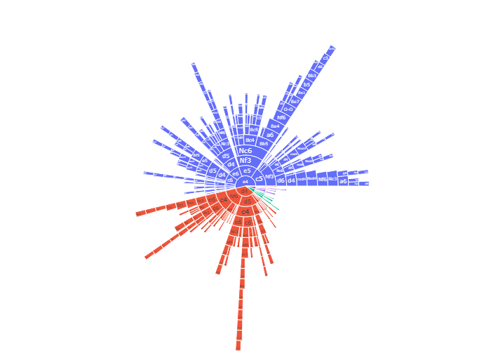

### Awards

Because winning isn’t everything; it’s the only thing :)

See the footnote for further details on selected awards.[^7]

| Award | Description | Winner | Details | Honourable mentions |
| --- | --- | --- | --- | --- |
| x | Archbishop of Accuracy | IsaVulpes | 19.2 ACPL over 364 moves | ebrankoftis, MoistvonLipwig |
| x | Awesome Alt | DHNL, Isachess, jameslatham, krxou, morallygray, SarahWynn | Played for 3 different teams | AleksisKaarlo, AUroach, Board_13, Boomer34, erv123, Grzybozbur, jervaelski, jivey, jrvdwjr, leobkho, lovlas, matrix47, mohityadav143, MrMaps, RandomiteTandomite0, show_me_patzer, SMNs, supermaths, Vla… |
| x | Bullet Boss | jessehf | 27 moves | toni4127, NoNameK |
| x | David Award | DMSA_OR | Opponents' record: 23/29 | morallygray, JoeyMellberg |
| x | Egalitarian Award | Return of the Sac | SD: 99.3 |  |
| x | Gambit Guru |  | Can't be awarded |  |
| x | Giri Award | ChessPatzerFrance, ChessPatzerSwan, ErinYu, IsaVulpes, mcastellani18, menzc, roso97, Sonata2, titan_twelve | 4 draws |  |
| x | Grischuk's Cousin | Anjablaserr | Had 15m 45s left after 10 moves | DMSA_OR, Ixitixl |
| x | Houdini Award | GuyIncognito_de |  | kostasvl, xobeci |
| x | Intimate with Increment | michaeltallovsky | 33.5% | pepepibote, KMisener |

[output cut: 10 more lines]

### Detailed statistics

All the following tables are sortable and searchable.

#### Team statistics

[output not shown]

[output cut: 18 more lines]

#### Best performances / highest accuracy

##### Best relative perfs

Shows players’ *relative* performance ratings: season performance rating minus initial rating.[^8]

*Includes all players with a positive relative performance rating over at least five games.*

| # | Player | Games | W | D | L | Initial | Perf | Diff. |
| --- | --- | --- | --- | --- | --- | --- | --- | --- |
| 1 | xobeci | 7 | 7 | 0 | 0 | 1742 | 2569.85714285714 | 827.857142857143 |
| 2 | LucaGaglia73 | 6 | 6 | 0 | 0 | 1502 | 2156.5 | 654.5 |
| 3 | mohityadav143 | 5 | 4 | 1 | 0 | 1349 | 1813.4 | 464.4 |
| 4 | leo2dipikke | 7 | 6 | 0 | 1 | 1572 | 1925.85714285714 | 353.857142857143 |
| 5 | Brundd | 5 | 4 | 1 | 0 | 1739 | 2061 | 322 |
| 6 | darubaru | 8 | 6 | 0 | 2 | 1311 | 1626.875 | 315.875 |
| 7 | GuyIncognito_de | 8 | 6 | 1 | 1 | 1542 | 1848.5 | 306.5 |
| 8 | oddskill | 6 | 5 | 0 | 1 | 1700 | 2000 | 300 |
| 9 | Edwarde | 7 | 5 | 1 | 1 | 1722 | 2011.57142857143 | 289.571428571429 |
| 10 | oddsox | 6 | 5 | 0 | 1 | 1604 | 1865.66666666667 | 261.666666666667 |

[output cut: 90 more lines]

##### Lowest ACPL

*Includes the 100 players with the lowest ACPL (min. 100 moves played).*

| Rank | Player | Moves | ACPL |
| --- | --- | --- | --- |
| 1 | IsaVulpes | 364 | 19.2005494505494 |
| 2 | ebrankoftis | 135 | 19.8 |
| 3 | MoistvonLipwig | 434 | 20.9861751152074 |
| 4 | tushar20008 | 193 | 21.300518134715 |
| 5 | Assassin_in_White | 310 | 21.4387096774194 |
| 6 | mcastellani18 | 247 | 21.5748987854251 |
| 7 | jameslatham | 184 | 22.4945652173913 |
| 8 | Wahlkatalane | 145 | 23.3310344827586 |
| 9 | SpeedCobra | 280 | 23.925 |
| 10 | ErinYu | 317 | 24.1577287066246 |

[output cut: 90 more lines]

#### Time spent / strongest opponents

##### Time spent

*Includes the 50 players who spent the most clock time over the season.*

| Rank | Player | Games | Total time spent |
| --- | --- | --- | --- |
| 1 | izzie26 | 9 | 10h 30m 8s |
| 2 | slamjam | 8 | 10h 8m 51s |
| 3 | IsaVulpes | 8 | 9h 45m 32s |
| 4 | Calcium237 | 8 | 9h 42m 37s |
| 5 | adande1 | 8 | 9h 36m 12s |
| 6 | MoistvonLipwig | 8 | 9h 32m 0s |
| 7 | shakaali | 8 | 9h 31m 18s |
| 8 | pepepibote | 8 | 9h 30m 56s |
| 9 | jessehf | 8 | 9h 27m 55s |
| 10 | Sesquipedalism | 8 | 9h 24m 39s |

[output cut: 40 more lines]

##### Time spent per move (after move 10)

*Includes everyone who played at least three games.*

| Rank | Player | Games | Moves | Time spent per move | Percentile |
| --- | --- | --- | --- | --- | --- |
| 1 | KN960 | 7 | 155 | 2m 31.3s | 100 |
| 2 | krxou | 3 | 49 | 2m 22.2s | 100 |
| 3 | RookTown | 5 | 101 | 2m 17.1s | 99 |
| 4 | ChristopherChabris | 7 | 144 | 2m 15.2s | 99 |
| 5 | mixxanber | 7 | 146 | 2m 9.9s | 98 |
| 6 | Napoleon_Solo | 3 | 83 | 2m 9.5s | 98 |
| 7 | f1nn33 | 6 | 167 | 2m 9.1s | 97 |
| 8 | Rolihlahla | 7 | 146 | 2m 8.9s | 97 |
| 9 | Scarff | 8 | 174 | 2m 5.7s | 96 |
| 10 | rsava | 3 | 37 | 2m 4.9s | 96 |

[output cut: 207 more lines]

##### Strength of schedule

These players faced the most in-form opponents across the season, when judged by their opponents’ collective score in all their other games.[^9]

*Includes all players who faced a collective group of opponents that played at least 15 (other) games across the season with a collective score above 50 per cent.*

| # | Player | Opp Games | Opp Pts | Opp % |
| --- | --- | --- | --- | --- |
| 1 | DMSA_OR | 29 | 23 | 79.3103448275862 |
| 2 | morallygray | 21 | 15.5 | 73.8095238095238 |
| 3 | JoeyMellberg | 20 | 14 | 70 |
| 4 | The_Italian_Dream | 25 | 17 | 68 |
| 5 | ssyx | 22 | 14.5 | 65.9090909090909 |
| 6 | okei | 44 | 28.5 | 64.7727272727273 |
| 6 | Tsatsa64 | 44 | 28.5 | 64.7727272727273 |
| 7 | ed84 | 56 | 36 | 64.2857142857143 |
| 7 | k-night-moves | 49 | 31.5 | 64.2857142857143 |
| 8 | mohityadav143 | 29 | 18.5 | 63.7931034482759 |

[output cut: 91 more lines]

#### Comebacks and upsets

##### Comebacks

*Includes players with a positive average “comeback margin” that played at least three games.*[^10]

| Rank | Player | Average Comeback Margin | Total Comeback Margin |
| --- | --- | --- | --- |
| 1 | GuyIncognito_de | 1.15140896814875 | 9.21127174519 |
| 2 | kostasvl | 1.12829524762613 | 9.02636198100902 |
| 3 | xobeci | 1.26285815440006 | 8.84000708080043 |
| 4 | leo2dipikke | 1.02618885964896 | 8.20951087719172 |
| 5 | BlackCat700 | 1.02184016007636 | 8.17472128061085 |
| 6 | cerulean | 0.985236145965547 | 7.88188916772437 |
| 7 | oddskill | 1.31216902706307 | 7.87301416237844 |
| 8 | Sesquipedalism | 0.98134868760116 | 7.85078950080928 |
| 9 | sanganakam | 0.958758986878025 | 7.6700718950242 |
| 10 | leinax | 0.84894873886198 | 7.64053864975782 |

[output cut: 205 more lines]

##### Biggest upsets

*Includes all players who defeated an opponent rated at least 50 points higher.*

| Rank | Player | Upset Margin |
| --- | --- | --- |
| 1 | darubaru | 265 |
| 2 | yvettenicole | 248 |
| 3 | Prof_Moriarty | 222 |
| 4 | IsaVulpes | 197 |
| 5 | mohityadav143 | 195 |
| 6 | Anjablaserr | 171 |
| 7 | IsaVulpes | 162 |
| 8 | darubaru | 141 |
| 9 | Tsatsa64 | 139 |
| 10 | gotthatplymouthrock | 137 |

[output cut: 100 more lines]

##### Repeated upsets

Includes players who achieved multiple wins over opponents rated at least 50 points higher.

| Rank | Player | Total Upset Margin | Upsets | Avg Upset Margin | Biggest Margin |
| --- | --- | --- | --- | --- | --- |
| 1 | darubaru | 532 | 3 | 177.333333333333 | 265 |
| 2 | QuietStorm24 | 450 | 5 | 90 | 137 |
| 3 | IsaVulpes | 359 | 2 | 179.5 | 197 |
| 4 | mohityadav143 | 331 | 2 | 165.5 | 195 |
| 5 | toni4127 | 292 | 3 | 97.3333333333333 | 130 |
| 6 | MoiRon | 285 | 3 | 95 | 109 |
| 7 | Anjablaserr | 281 | 2 | 140.5 | 171 |
| 8 | Finneri | 278 | 3 | 92.6666666666667 | 104 |
| 9 | gotthatplymouthrock | 254 | 2 | 127 | 137 |
| 10 | freddy267t | 246 | 3 | 82 | 98 |

[output cut: 15 more lines]

#### Dawdlers and instant movers

##### Least time left after move 10

The players with the least time left after 10 moves…who still managed to win![^11]

| Rank | Player | Time left after 10 moves | Link |
| --- | --- | --- | --- |
| 1 | Anjablaserr | 15m 45s | https://lichess.org/QvJIr24Y#19 |
| 2 | DMSA_OR | 17m 56s | https://lichess.org/YUS51U19#20 |
| 3 | Ixitixl | 22m 5s | https://lichess.org/gE8Yp2zk#19 |
| 4 | AraPawn | 22m 50s | https://lichess.org/JCTUcIqu#19 |
| 5 | KMisener | 25m 0s | https://lichess.org/vOdtNTRZ#20 |
| 6 | colwem | 26m 14s | https://lichess.org/dRNfDs1W#20 |
| 7 | TheRatRiverTrapper | 26m 19s | https://lichess.org/Zkt6cNDv#19 |
| 8 | H0tblackDesiat0 | 26m 39s | https://lichess.org/Evh9pmuI#20 |
| 9 | jmcampbell | 26m 45s | https://lichess.org/ak6XY0FK#20 |
| 10 | Finneri | 27m 3s | https://lichess.org/BYlSNKB1#19 |

##### Instant moves

Players who made the most ‘instant’ moves over the season, taking less than 0.5 seconds (includes premoves).

*Includes players with more than five ‘instant’ moves.*

| Rank | Player | Instant moves |
| --- | --- | --- |
| 1 | jessehf | 27 |
| 2 | toni4127 | 26 |
| 3 | NoNameK | 23 |
| 4 | badplayer_CM | 22 |
| 4 | FairyTaleTime | 22 |
| 5 | david252525 | 20 |
| 6 | Mahmut69 | 17 |
| 7 | shakaali | 16 |
| 8 | furrykef | 15 |
| 8 | k-night-moves | 15 |

[output cut: 58 more lines]

#### Longest thinks, time trouble addicts, and lucky escapes

##### Longest thinks

The longest times spent on a single move.

*Top 100 shown.*

| # | Player | Time spent | Colour | Move | Link |
| --- | --- | --- | --- | --- | --- |
| 1 | dmavro | 32m 31s | White | 15 | https://lichess.org/sgoUkVMr#29 |
| 2 | KN960 | 28m 26s | White | 20 | https://lichess.org/VzptevpW#39 |
| 3 | Anjablaserr | 26m 34s | Black | 26 | https://lichess.org/mcSxIdVp#52 |
| 4 | mynameismund | 26m 22s | Black | 30 | https://lichess.org/09tcqPMP#60 |
| 5 | Forhavu | 26m 10s | White | 13 | https://lichess.org/Ommu6KQC#25 |
| 6 | kostasvl | 25m 30s | Black | 13 | https://lichess.org/zV7UwuJl#26 |
| 7 | astralfenix | 25m 20s | Black | 20 | https://lichess.org/VzptevpW#40 |
| 8 | Seb32 | 24m 42s | Black | 15 | https://lichess.org/epKXHeT7#30 |
| 9 | KN960 | 22m 26s | Black | 15 | https://lichess.org/iLk58ymV#30 |
| 10 | okei | 22m 15s | White | 10 | https://lichess.org/u3TAAjck#19 |

[output cut: 90 more lines]

##### Time trouble addicts

Shows players by proportion of moves made in time trouble (defined as having less than a minute remaining on the clock).

*Includes everyone who played at least 100 moves over the season while making at least one move in time trouble.*

| # | Player | All moves | With < 1min left | Time Trouble % |
| --- | --- | --- | --- | --- |
| 1 | michaeltallovsky | 343 | 115 | 0.335276967930029 |
| 2 | pepepibote | 323 | 93 | 0.287925696594427 |
| 3 | KMisener | 281 | 72 | 0.256227758007117 |
| 4 | Sleivert | 260 | 61 | 0.234615384615385 |
| 5 | izzie26 | 393 | 74 | 0.188295165394402 |
| 6 | k-night-moves | 310 | 52 | 0.167741935483871 |
| 7 | Traxxin | 225 | 35 | 0.155555555555556 |
| 8 | JoeyMellberg | 184 | 28 | 0.152173913043478 |
| 9 | seius | 229 | 34 | 0.148471615720524 |
| 10 | KnightyKnight1996 | 320 | 47 | 0.146875 |

[output cut: 82 more lines]

##### Saved by the bell

Players who made moves with under 5 seconds left on their clock…and still won![^12]

| Player | Moves with under 5s left | Least time left | Link |
| --- | --- | --- | --- |
| KMisener | 4 | 4 | https://lichess.org/x9cWAlZg |
| KnightyKnight1996 | 3 | 2 | https://lichess.org/QKyZ0VeR |
| Traxxin | 2 | 1 | https://lichess.org/3PlkxYBC |
| oddsox | 2 | 2 | https://lichess.org/YddzQbsB |
| pepepibote | 2 | 2 | https://lichess.org/Ti4AmtBs |
| val1313 | 1 | 1 | https://lichess.org/q1oCQuLj |
| IsaVulpes | 1 | 1 | https://lichess.org/ePULCBBr |
| Sesquipedalism | 1 | 3 | https://lichess.org/cPrE1xbc |
| k-night-moves | 1 | 5 | https://lichess.org/DSZnlSJb |
| JoeyMellberg | 1 | 5 | https://lichess.org/xqlmCeYN |

#### Misc. facts

##### Lesser spotted mates

A pawn gave checkmate in 8 games: https://lichess.org/AFg9r16D, https://lichess.org/SbWa7uYh, https://lichess.org/wdYS6FmK, https://lichess.org/e9x1txmN, https://lichess.org/HE62IpWP, https://lichess.org/HR5RY57m, https://lichess.org/FAiFz078, https://lichess.org/7C76Q7gr.

A knight gave checkmate in 4 games: https://lichess.org/asX62qPT, https://lichess.org/7EeuMx34, https://lichess.org/IFTeQYJL, https://lichess.org/ajjz9US7.

##### Promotions

80 games had at least one promotion. 1 of these saw an under-promotion.

The most promotions seen in a game was 4: https://lichess.org/4rYe1JiZ

##### Rollercoaster games

66 games featured significant winning chances for both sides (as identified by Lichess’s server analysis), comprising 8.2% of all games played.

##### Checks and captures

- Most consecutive checks: 12 (https://lichess.org/6a1aaB3q)
- Most consecutive captures: 12 (https://lichess.org/zobF1mR7)
- Latest-occurring first capture: ply 42 in https://lichess.org/lJ7JUsBy

### About this report

- This report was compiled on 16 August 2021.
- These statistics are presented for general interest only. They are not guaranteed to be comprehensive, complete[^13], accurate, or up to date. They may be periodically revised to incorporate updates and bugfixes.
- Any player determined by Lichess to have violated their Terms of Service when this report was compiled should not appear in the detailed statistics.[^14]
- [Homepage](https://rahulan-c.github.io/lichess4545-stats/) / [source code](https://github.com/rahulan-c/lichess4545-stats)
- Acknowledgements: [Noun Project](https://thenounproject.com/) for the award icons; [Simon Ilincev](https://simonilincev.com/) for chess_graph, which produces the openings sunburst plots.
[^1]: The forfeit rate is the percentage of pairings that didn’t result in a game being played.
[^2]: The number of games played in this statistic can differ from the number of games played in the season, as it excludes games where the result of the pairing was later changed to a forfeit win or loss.
[^3]: The performance ratings in this table only take into account games played on the relevant board, which is why they differ from (and should be preferred to) the ratings given by the board standings tables on the Lichess4545 website.
[^4]: A game’s total clock time is the sum of both players’ move times from move 2 onwards.
[^5]: Currently, gambit openings are identified by the presence of the term *gambit* in the opening name assigned by Lichess. This is admittedly an imperfect approach as it excludes certain openings that should also be considered as gambits such as the Marshall Attack.
[^6]: Qualifying “gambiteers” are ordered by number of gambit games played before percentage score.
[^7]: *Archbishop of Accuracy*: lowest average centipawn loss (ACPL) over all moves played, as determined by Lichess’s server analysis. Minimum 100 moves played. *David Award*: the player whose opponents achieved the highest percentage score across the season, excluding games against the player. One’s opponents must have played over 20 games (against others) to qualify. Suggested by Tranzoo. *Egalitarian Award*: intended for the team whose players performed most similarly to each other. First, I compute all players’ *relative* performance ratings – the difference between their actual performance rating (using FIDE’s method) and their initial rating. Then I group all players by team, and give the award to the team with the lowest standard deviation across its players’ relative ratings. Suggested by Silkthewanderer. *Gambit Guru*: most gambits played while scoring above 50%. *MVP Award*: minimum 5 games played. *Rookie Award*: minimum 4 games played. *Saved by the Bell*: Excludes moves made in positions with an evaluation of under +300 centipawns from the mover’s perspective. Ordering is determined first by # moves played with under 5 seconds remaining, then by least time remaining in such conditions, then by worst eval faced. *Slingshot Specialist*: the player with the highest total rating gap between their opponents and themselves when only considering wins against opponents rated at least 50 rating points higher.︎
[^8]: The season performance ratings presented in this report may differ slightly from the figures given by the Lichess4545 website. Both figures are based on FIDE’s preferred calculation method and exclude unplayed games (such as forfeit wins/losses and scheduling draws.
[^9]: Both the statistic and the name of its associated award – the David Award – were suggested by **Tranzoo**.
[^10]: Originally suggested by **Lou-E**. This table shows players ranked by the size and number of comebacks achieved over the course of the season. For this purpose, the size of a comeback has been defined as the difference between a player’s final score in a game (0, 0.5, or 1) and the worst evaluation during the game that they faced (which is then converted into a rough win probability for their opponent). For example, if I were to win a game after Lichess’s server analysis gave my opponent a 75% chance of winning in a certain position, then I would have earned 1.75 comeback “points” from the game. My opponent of course would have earned zero points. If the game had been drawn, I would have instead earned only 0.75 comeback “points”.
[^11]: Statistic suggested by **Silkthewanderer**.
[^12]: Excludes moves made in technically winning positions, defined as $\tt eval \le 300$ (from the mover’s perspective). Players are first ordered by number of moves made with 5 seconds or fewer remaining, then by least time remaining in such conditions, and finally by worst eval faced.
[^13]: For example, this report excludes from its analysis all games of less than 5 plies (half-moves), games that ended in a disconnection or by “cheat detected”, games that were aborted, and games that started from a custom position.
[^14]: However, players who were banned from the Lichess4545 leagues after finishing a season in the top three places are still shown with a podium place in that season’s report.